# Data607_Proj2

Data607_Proj2 Alice Friedman October 14, 2018

## Setup

```r
library(knitr)
library(kableExtra)
library(prettydoc)
library(RCurl)
library(dplyr)
library(ggplot2)
library(forcats)
library(varhandle)
library(stringr)
```

## Kaggle ML and Data Science Survey

Kaggle conducted a survey of more than 16,000 data scientists in 2017. Data used in the following analysis is pulled from https://www.kaggle.com/kaggle/kaggle-survey-2017.

### At work, what proportion of your analytics projects incorporate data visualization?

One way to determine how important a particular skill is to data scientsists is to look at how much of working data scientists’ job uses that skill. One question the survey asks is, “At work, what proportion of your analytics projects incorporate data visualization?”

As the analysis shows below, the largest number of response by far is that more than three-quarters of all the respondents’s assigned projects incorporate data visualization. Data visualization must be an imrportant skill!

```r
Kaggle.Multi <- read.csv("https://raw.githubusercontent.com/aliceafriedman/DATA607_Proj3/master/multipleChoiceResponses.csv", sep=",", header = TRUE)
```

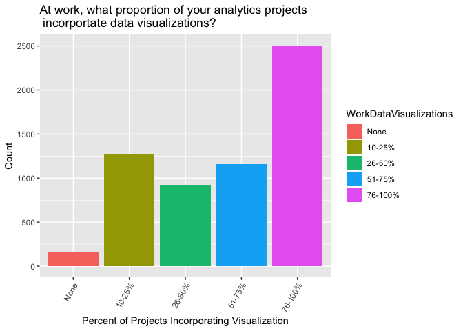

```r
PercOrder <- c(
"None",
"10-25% of projects",
"26-50% of projects",
"51-75% of projects",
"76-99% of projects",
"100% of projects")

Kaggle.Multi$WorkDataVisualizations <- factor(Kaggle.Multi$WorkDataVisualizations, PercOrder)

Kaggle.Multi %>%
  filter(WorkDataVisualizations!="") %>%
  mutate(WorkDataVisualizations = fct_recode(WorkDataVisualizations,
    "10-25%" = "10-25% of projects",
    "26-50%" = "26-50% of projects",
    "51-75%" = "51-75% of projects",
    "76-100%" = "76-99% of projects",
    "76-100%" = "100% of projects"
  )) %>%
  ggplot(aes(WorkDataVisualizations))+
  geom_bar(aes(fill=WorkDataVisualizations))+
  theme(axis.text.x=element_text(angle = 60, hjust = 1))+
  labs(title = "At work, what proportion of your analytics projects\n incorportate data visualizations?",
       x = "Percent of Projects Incorporating Visualization",
       y = "Count")
```

### Who responded to this survey?

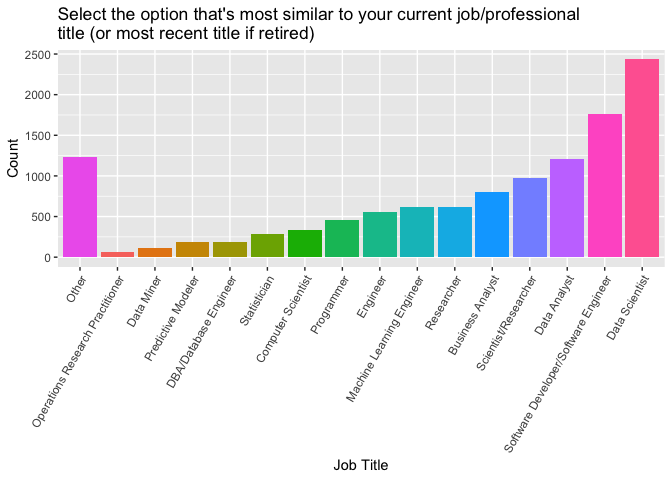

```r
Kaggle.Multi %>%
  filter(CurrentJobTitleSelect!="") %>%
  mutate(CurrentJobTitleSelect = CurrentJobTitleSelect %>% fct_infreq() %>% fct_rev()) %>%
  ggplot(aes(fct_relevel(CurrentJobTitleSelect, "Other")))+
  geom_bar(aes(fill=CurrentJobTitleSelect))+
  theme(axis.text.x=element_text(angle = 60, hjust = 1), legend.position="none")+
  labs(title = "Select the option that's most similar to your current job/professional \ntitle (or most recent title if retired)",
       x= "Job Title",
       y = "Count")
```

## Salary Data

Another way to look at skills is to see how answers vary by salary. The most important skills should draw a higher salary.

This data requires a bit of munging, as salaries have been reported in several currencies, and a quick look at the repsonses seems to indicate that many individuals have entered there salaries in “thousands” whereas others have entered it in dollars. Some of the responses are in the millions. Are these liars, or just very well paid survey respondents?

To address the former, we will filter by responses reported in USD. To address the two latter, we have a options:

1. Ignore outliers (e.g. responses less than $1000, and more than $1,000,000)
2. Assume that everyone is telling the truth about their salaries
3. Assume that responses less than $1000 are reporting in thousands (e.g. a response of $87 is intended to mean a salary of $87,000, something which would be expected based on overall salary data for data scientists)
4. Some combination of the above, taking into account known salary distributions for particular titles.

The data munging to access US reported salaries also must take into account that data has been entered in a varirty of formats, resulting in data that cannot be easily converted to numeric.

First, let’s investigate the data to see which of these options is most reasonable.

```r
USSalaries <- Kaggle.Multi %>% filter(CompensationCurrency=="USD") %>%
  select(CompensationAmount) %>%
#First, we must unfactor the data using the varhandle library
  mutate(CompensationAmount = unfactor(CompensationAmount),
#Then, we must remove all commas, which are included in some, but not all, data entries before we can finally convert to numeric
         CompensationAmount = str_remove_all(CompensationAmount,","),
         CompensationAmount = as.numeric(CompensationAmount))
quantile(USSalaries[[1]], na.rm = TRUE)
```

```
##      0%     25%     50%     75%    100%
##       0   60000   96000  140000 9999999
```

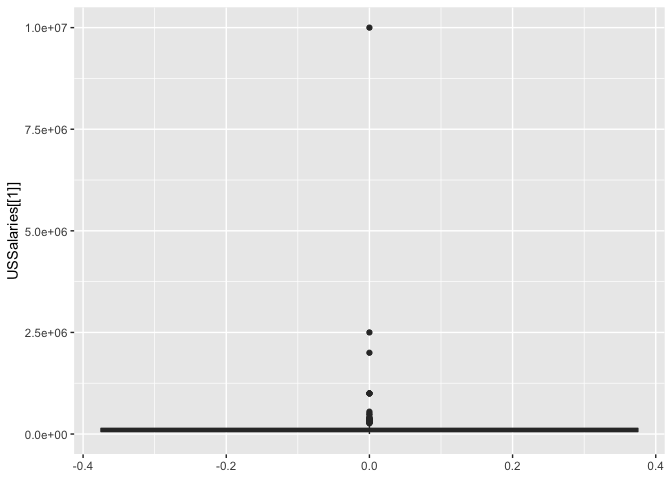

```r
ggplot(USSalaries, aes(y = USSalaries[[1]]))+geom_boxplot()
```

The entry “9999999” seems obviously to be a false entry, and a number of the other outliers seems implausible as well. How many reported salaries are more than $1M?

```r
USSalariesTest <- USSalaries %>% filter(USSalaries > 1000000)
USSalariesTest
```

```
##   CompensationAmount
## 1            9999999
## 2            2500000
## 3            2000000
```

Only 3! Seems plausible that 2 people out of more than 16,000 respondents could earn more than $1M, I will assume those are real entries. I will exclude the “9999999” entry, and rerun the results.

```r
USSalaries <- USSalaries %>% filter(USSalaries != 9999999)
quantile(USSalaries[[1]], na.rm = TRUE)
```

```
##      0%     25%     50%     75%    100%
##       0   60000   96000  140000 2500000
```

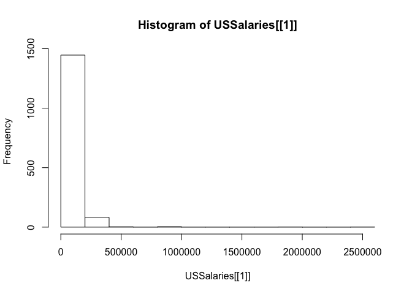

```r
hist(USSalaries[[1]])
```

### How many people report less than $1000 in salary?

```r
USSalariesTest2 <- USSalaries %>% filter(USSalaries >0 & USSalaries < 1000)
USSalariesTest2
```

```
##    CompensationAmount
## 1                 205
## 2                 155
## 3                  96
## 4                  80
## 5                 485
## 6                 102
## 7                 185
## 8                 100
## 9                 110
## 10                900
## 11                265
## 12                  1
```

Since the number of entries less than $1000 is small (12), I will exclude them from the dataset rather than convert to thousands.

```r
USSalaries <- USSalaries %>% filter(USSalaries < 9999999 & USSalaries > 0)
quantile(USSalaries[[1]], c(.1, .2, .3, .4, .5, .6, .7, .8, .9), na.rm = TRUE)
```

```
##    10%    20%    30%    40%    50%    60%    70%    80%    90%
##  28000  50000  69300  83000  96000 110000 130000 150000 185000
```

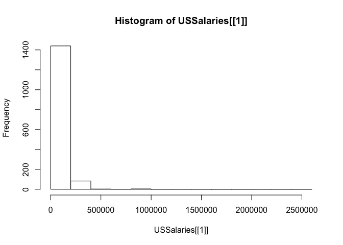

```r
hist(USSalaries[[1]])
```

```r
Kaggle.Multi %>%
  mutate(CompensationAmount = as.numeric(as.numeric(levels(CompensationAmount)[CompensationAmount])),
         CompensationAmount = ifelse(CompensationAmount < 100, CompensationAmount*1000, CompensationAmount)) %>%
  filter(CompensationCurrency=="USD",
         CompensationAmount < 1000000) %>%
  glimpse()
```

[output not shown]

[output cut: 215 more lines]

```r
  #
   # ggplot(aes(fct_relevel(CurrentJobTitleSelect, "Other")))+
  #geom_bar(aes(fill=CurrentJobTitleSelect))+
  #theme(axis.text.x=element_text(angle = 60, hjust = 1), legend.position="none")+
  #labs(title = "Select the option that's most similar to your current job/professional \ntitle (or most recent title if retired)",
 #      x= "Job Title",
#       y = "Count")
```